# Data Importing Cleaning, and Data Visualization

# Demonstration table

# linked up.

Skill

Problems Demonstrated

I can modify existing variables and create new variables in a dataframe for a variety of data types (e.g., numeric, integer, character, factor, date).

- Hip Hop data set step 4.
- Rodent Ecological Study: problem 3

I can find summaries of variables across multiple groups.

applying functions

- rescaled length plot

Utilizing Functions

# Functions and Fish

The data set used in this section of code includes the fish captured and tagged in various trip from 1989 to 2006 on the Johnsrud and Scotty Brown sections of the Black Foot river. The length, weight, the year it was caught, the section of the river, what number trip of the year it was, and if it had already been marked were recorded for each fish.

## Locating Missing Data

The missing function written below identifys the quantity of missing data for a single variable. It does this by summing the number of NAs within a column.

```r
missing <- function(x) {
  sum(is.na(x))
}
```

The next code chunk applies the missing function across all of the factors. The table is then pivoted so the factors are now a variable and the number of missing data points is another variable. Finally the table is arranged in descending order by the number of missing data points.

```r
fish |>
  mutate(
    across(
      .cols = everything(), .fns = ~(missing(.x))
    )
    ) |>
  distinct(weight, .keep_all = TRUE) |>
  pivot_longer(
    cols = everything(),
    names_to = "Observation Type",
    values_to = "Missing Data Points"
    ) |>
  arrange(desc(`Missing Data Points`))
```

```
# A tibble: 7 × 2
  `Observation Type` `Missing Data Points`
  <chr>                              <int>
1 weight                              1796
2 trip                                   0
3 mark                                   0
4 length                                 0
5 year                                   0
6 section                                0
7 species                                0
```

### missing data visualization

The visual generated by the next code chunk represents which variables explain most of the missing data.  
the variables included in the visual are the river section, the year and the trip.

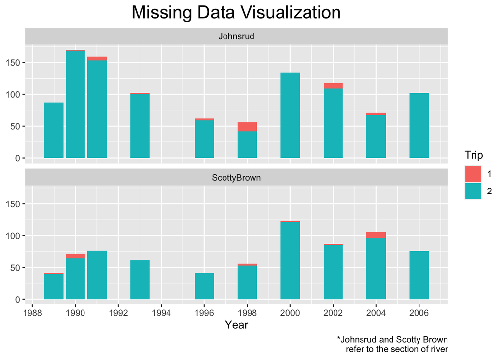

```r
my_title <- theme(plot.title = element_text(hjust = 0.5, size = 18))

missing_fish <- fish |>
  filter(is.na(weight == 0)) |>
  group_by(section, trip, year) |>
  summarize(weight = sum(is.na(weight)), .groups = "keep") |>
  ungroup() |>
  arrange(desc(year)) |>
  rename("missing" = "weight")

missing_fish |>
  mutate(trip = as.character(trip)) |>
  ggplot() +
    geom_col(mapping = aes(x = year,
                           y =  missing,
                           fill = trip)) +
    facet_wrap(~section, nrow = 2) +
    labs(title = "Missing Data Visualization",
         y = NULL,
         x = "Year",
         fill = "Trip",
         caption = "*Johnsrud and Scotty Brown
         refer to the section of river") +
  my_title +
   scale_x_continuous(
    breaks = scales::pretty_breaks(n = 10)
                     )
```

## **Part Two: Adjusting the Data (Function Writing)**

### a) Rescale function.

```r
rescale01 <- function(x){
  stopifnot(is.numeric(x) | (length(x) > 1) == TRUE) # add check.
  r <- range(x, na.rm = TRUE)
  (x - r[1]) / (r[2] - r[1])
}
```

### b) Simple check for `rescale01` function.

The function is applied to a data set containing the inetergers from 1 to 25 and 1 NA data point.

```r
x <- c(1:25, NA)
rescale01(x)
```

```
 [1] 0.00000000 0.04166667 0.08333333 0.12500000 0.16666667 0.20833333
 [7] 0.25000000 0.29166667 0.33333333 0.37500000 0.41666667 0.45833333
[13] 0.50000000 0.54166667 0.58333333 0.62500000 0.66666667 0.70833333
[19] 0.75000000 0.79166667 0.83333333 0.87500000 0.91666667 0.95833333
[25] 1.00000000         NA
```

### c) More difficult check

2 bar and whisker plots are created in the next code chunk. Both plots are visualization of the distribution of fish length from the fish data set. the first plot, the one with dark green fill, uses length data after the `rescale01` function was applied. the second plot uses the raw length data. All data points for the dark green plot fall between 0 and 1.

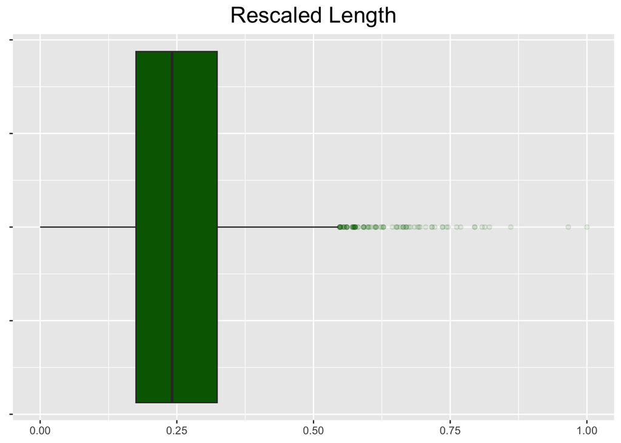

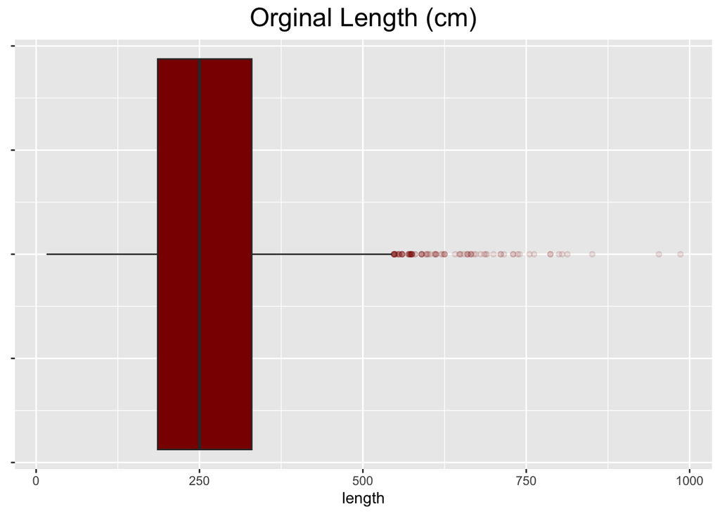

```r
fish |> mutate(rescaled = rescale01(length)) |>
  ggplot() +
  geom_boxplot(
    mapping = aes(x = rescaled), fill = "darkgreen",
    outlier.color = "darkgreen", outlier.alpha = 0.1
    ) +
  labs(title = "Rescaled Length", x = NULL) +
  theme(axis.text.y = element_text(size = 0)) +
  my_title
fish |>
  ggplot() +
  geom_boxplot(
    mapping = aes(x = length), fill = "darkred",
    outlier.color = "darkred",outlier.alpha = 0.1
    ) +
  labs(title = "Orginal Length (cm)") +
  theme(axis.text.y = element_text(size = 0)) +
  my_title
```

### Re-scale function for columns within a data frame.

The `rescale0` function from earlier could be applied to a `df` if used within the `mutate( )` function. the `rescale_column` function below can be applied to a set of columns within a data frame without using the mutate function.

```r
rescale_column <- function(df, var) {
  df <- df |> mutate(
                across(
                  .cols = {{ var }},
                  .fns = rescale01
                )
    )

  return(df)
}
```

#### `rescale_column` applied.

Below are two lines of code that produce the same data frame.  
The first line of code compared to the second exemplifies the outcome of efficient code and the importance of the function tool for creating concise code. The difference could be much more pronounced more variable needed to be resclaed.

```r
fish |> rescale_column(c(length, weight))
```

```
# A tibble: 18,352 × 7
    trip  mark length  weight  year section  species
   <dbl> <dbl>  <dbl>   <dbl> <dbl> <chr>    <chr>
 1     1     0  0.280 0.0374   1989 Johnsrud RBT
 2     1     0  0.280 0.0406   1989 Johnsrud RBT
 3     1     0  0.277 0.0524   1989 Johnsrud RBT
 4     1     0  0.315 0.0588   1989 Johnsrud RBT
 5     1     0  0.305 0.0641   1989 Johnsrud RBT
 6     1     0  0.358 0.0812   1989 Johnsrud RBT
 7     1     0  0.261 0.0363   1989 Johnsrud RBT
 8     1     0  0.148 0.00855  1989 Johnsrud RBT
 9     1     0  0.203 0.0171   1989 Johnsrud RBT
10     1     0  0.145 0.00748  1989 Johnsrud RBT
# ℹ 18,342 more rows
```

```r
fish |> mutate(length = rescale01(length),
               weight = rescale01(weight))
```

```
# A tibble: 18,352 × 7
    trip  mark length  weight  year section  species
   <dbl> <dbl>  <dbl>   <dbl> <dbl> <chr>    <chr>
 1     1     0  0.280 0.0374   1989 Johnsrud RBT
 2     1     0  0.280 0.0406   1989 Johnsrud RBT
 3     1     0  0.277 0.0524   1989 Johnsrud RBT
 4     1     0  0.315 0.0588   1989 Johnsrud RBT
 5     1     0  0.305 0.0641   1989 Johnsrud RBT
 6     1     0  0.358 0.0812   1989 Johnsrud RBT
 7     1     0  0.261 0.0363   1989 Johnsrud RBT
 8     1     0  0.148 0.00855  1989 Johnsrud RBT
 9     1     0  0.203 0.0171   1989 Johnsrud RBT
10     1     0  0.145 0.00748  1989 Johnsrud RBT
# ℹ 18,342 more rows
```

.

# Hip-hop data set

## 1. Introduction:

The data set analyzed in today’s lab is from a project that aimed to predict music taste based on how familiar a person is with 64 words from African American English. The data set was complied by asking participants to report their familiarity, on a scale from 1 to 6, for a set of 64 words.

## 2. what are the rows?

A row is created for each participant-word pairing.

## 3. What are missing values replaced with?

Missing values were replaced with mean values. This is a good idea because it prevents outlying variables from over influencing the distribution of the data set, but it is an assumption.

## 4. cleaning data

```r
hiphop_clean <- hiphop |>
  mutate(
    across(where(is.character), as.factor)
    )
```

## 5. how many unique AAE words are there.

```r
hiphop_clean |>
  distinct(word, .keep_all = TRUE) |>
  count()
```

```
# A tibble: 1 × 1
      n
  <int>
1    64
```

## 6. white and non-white factor.

```r
hiphop_w <- hiphop_clean |>
  mutate(
    white = if_else(ethnic == "white", "white", "not white")
  )
```

## 7. Demographics

```r
demo <- hiphop_clean |>
  distinct(subj, .keep_all = TRUE) |>
  select(sex, age, ethnic)|>
  mutate(sex = as.factor(sex),
         ethnic = as.factor(ethnic)) |>
  select(sex, age, ethnic)
demo |>
  summary()
```

```
     sex           age             ethnic
 Female:117   Min.   :16.00   white   :135
 Male  : 51   1st Qu.:18.00   asian   : 19
              Median :19.00   african :  5
              Mean   :20.02   hispanic:  3
              3rd Qu.:20.00   indian  :  2
              Max.   :48.00   biracial:  1
                              (Other) :  3
```

```r
demo <- demo |>
  distinct(sex, age, ethnic, .keep_all = TRUE)

demo |>
  count()
```

```
# A tibble: 1 × 1
      n
  <int>
1    47
```

## 8. Demographic Plots

Visualization of data set demographics by sex, age, and ethnicity.

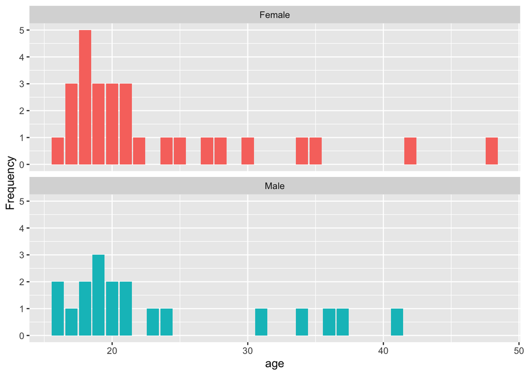

```r
#|plot_position: center
ggplot(data = demo) +
  geom_bar(
    mapping = aes(x = age, fill = sex),
    show.legend = FALSE
    ) +
  facet_wrap(~sex, nrow = 2) +
  ylab("Frequency")
```

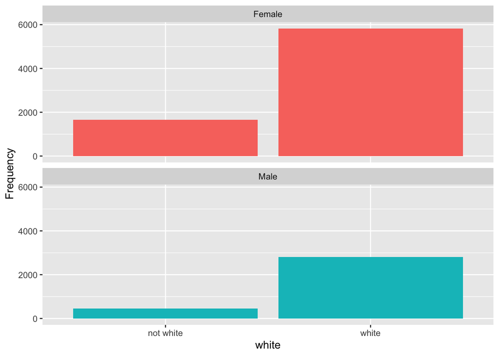

```r
ggplot(data = hiphop_w) +
  geom_bar(mapping = aes(x = white,
                         fill = sex),
           show.legend = FALSE) +
  facet_wrap(~sex, nrow = 2)+
  ylab("Frequency")
```

### Familiar words

```r
familiar <- hiphop_clean |>
  filter(age < 20) |>
  select(word,familiarity) |>
  group_by(word) |>
  summarise(mean_fam = mean(familiarity))
familiar |>
  slice_max(mean_fam)
```

```
# A tibble: 1 × 2
  word         mean_fam
  <fct>           <dbl>
1 off the hook     4.42
```

```r
familiar |>
  slice_min(mean_fam)
```

```
# A tibble: 1 × 2
  word             mean_fam
  <fct>               <dbl>
1 catch the vapors     1.03
```

```r
familiar <- hiphop_w |>
 filter(white == "not white",
        sex == "Female") |>
 select(word, familiarity) |>
 group_by(word) |>
 summarise(mean_fam = mean(familiarity))

familiar |>
 slice_max(mean_fam) |>
  print()
```

```
# A tibble: 1 × 2
  word    mean_fam
  <fct>      <dbl>
1 feel me     4.19
```

```r
familiar |>
 slice_min(mean_fam)
```

```
# A tibble: 4 × 2
  word              mean_fam
  <fct>                <dbl>
1 break someone out        1
2 dukey rope               1
3 plex                     1
4 rollie                   1
```

```r
familiar <- hiphop_w |>
 filter(white == "white",
        age > 30,
        sex == "Male") |>
 select(word, familiarity) |>
 group_by(word) |>
   summarise(mean_fam = mean(familiarity))

familiar |>
   slice_max(mean_fam)
```

```
# A tibble: 1 × 2
  word  mean_fam
  <fct>    <dbl>
1 5-0        4.2
```

```r
familiar |>
   slice_min(mean_fam)
```

```
# A tibble: 25 × 2
   word              mean_fam
   <fct>                <dbl>
 1 ay yo trip               1
 2 beezy                    1
 3 break someone out        1
 4 catch the vapors         1
 5 crossroads               1
 6 crump                    1
 7 dap                      1
 8 dollar cab               1
 9 domino                   1
10 duckets                  1
# ℹ 15 more rows
```

### Justin Bieber?

```r
hiphop_clean |>
  distinct(subj, .keep_all = TRUE) |>
  filter(age %in% 17:23,
         city %in% 10000:60000,
         sex == "Male",
         ethnic == "white") |>
  slice_max(order_by = bieber, n = 1) |>
  select(subj)
```

```
# A tibble: 1 × 1
  subj
  <fct>
1 p17
```

If Justin was in this study he would be participant #17.

# Rodent Ecological Study:

The Portal Project is a long-term ecological study being conducted near Portal, AZ. Since 1977, the site has been used to study the interactions among rodents, ants and plants and their respective responses to climate. To study the interactions among organisms, we experimentally manipulate access to 24 study plots. This study has produced over 100 scientific papers and is one of the longest running ecological studies in the U.S.

## 1. revisit lab 2

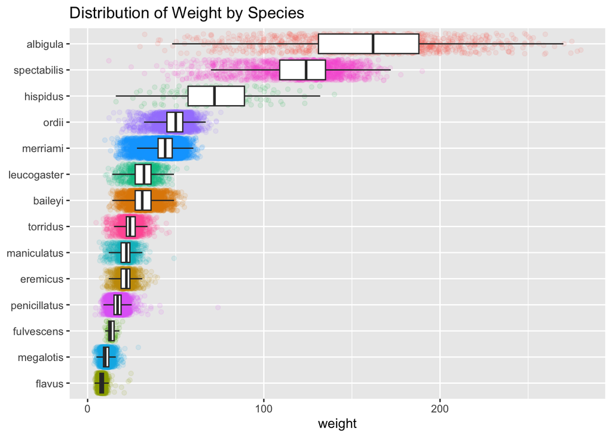

```r
surveys |>
  ggplot(
    data = surveys,
         mapping =
           aes(y = fct_reorder(species, weight, .desc = FALSE),
               x = weight)
    ) +
  geom_jitter(mapping = aes(color = species),
              alpha = .1, show.legend = FALSE) +
  geom_boxplot(outlier.shape = NA) +
  labs(title = "Distribution of Weight by Species", y = NULL)
```

## 2.Time-Series Plot

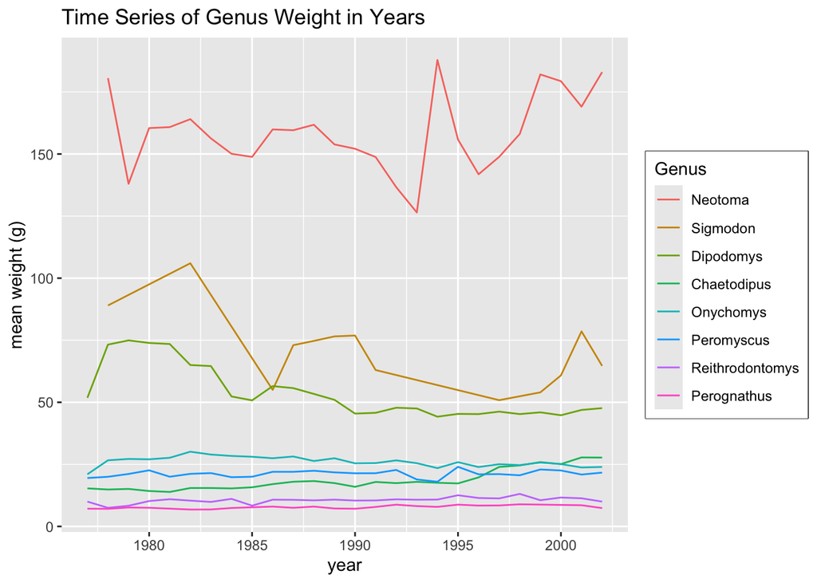

```r
surveys_clean <- surveys |>
  mutate(year = year(date),
         genus = as_factor(genus)) |>
  group_by(genus, year) |>
  summarise(mean_wt = mean(weight, na.rm = TRUE)) |>
  ungroup()

surveys_clean |> filter(!is.na(year)) |>
  ggplot(mapping = aes(year, mean_wt, color = fct_reorder2(genus, year, mean_wt))) +
  geom_line() +
  labs(color = "Genus")+
  ylab("mean weight (g)") +
  ggtitle("Time Series of Genus Weight in Years") +
  theme(legend.box.background = element_rect(fill = "grey"))
```

## 3.Captures of the Week

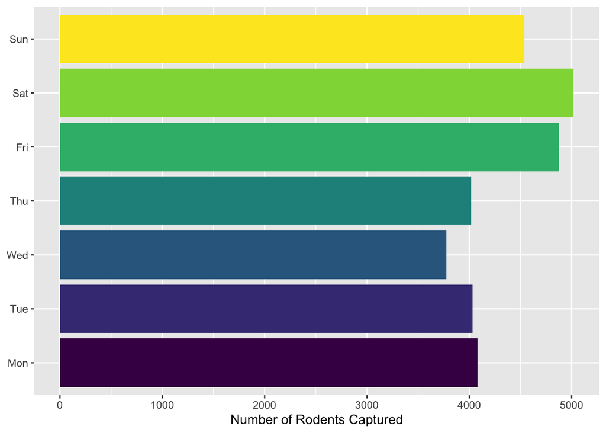

```r
day_levels <-
  c("Mon","Tue", "Wed", "Thu", "Fri", "Sat", "Sun" )

surveys_clean <- surveys |>
  mutate(date = make_date(date),
         days = wday(date, label = TRUE)) |>
  select(taxa, days) |>
  group_by(days) |>
  summarize(captures = n()) |>
  filter(days != "NA")

surveys_clean |>
  ggplot(
    mapping = aes(fct_relevel(days, day_levels), captures,
                  fill = fct_relevel(days, day_levels))
    ) +
  geom_col(show.legend = FALSE) +
  scale_x_discrete(drop = TRUE)+
  coord_flip() +
  labs(y = "Number of Rodents Captured", x = NULL)
```

## 2. weekend

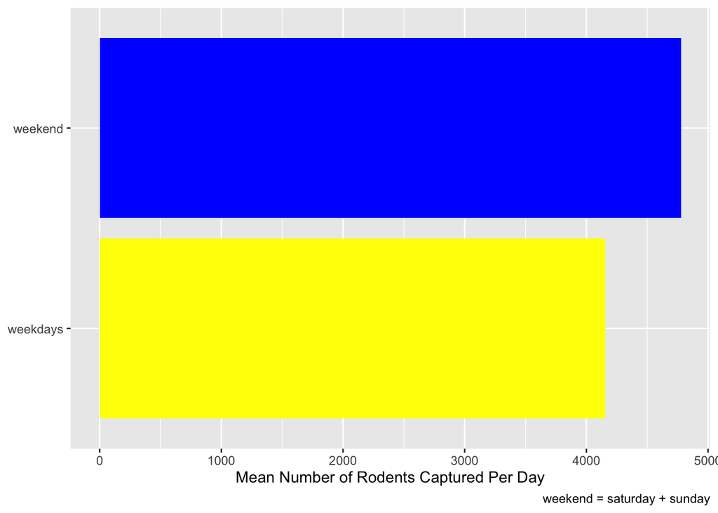

```r
surveys_clean <- surveys_clean |>
  mutate(days = fct_collapse(days,
                             weekdays = c("Mon","Tue", "Wed",
                                          "Thu", "Fri"),
                             weekend = c("Sat", "Sun"))) |>
  group_by(days) |>
  summarise(AverageCaptures = mean(captures))

surveys_clean |>
  ggplot(mapping = aes(
    fct_reorder(days, AverageCaptures, .desc = FALSE),
    AverageCaptures)) +
  geom_col(fill = c("blue", "yellow")) +
  scale_x_discrete(drop = TRUE) +
  coord_flip() +
  labs(caption = "weekend = saturday + sunday",
       y = "Mean Number of Rodents Captured Per Day",
       x = NULL)
```

# Baby Name Data Set:

```r
rm(list = ls())
library(tidyverse)
bb_names <- read_csv(here::here("supporting_artifacts", "ref.work", "lab9", "StateNames_A.csv"))
bb_names <- bb_names |> rename("Sex" = "Gender")
```

# 1 Creating table

This table takes a closer look at babies who received the name Allison and if their Sex was Male or Female.

```r
bb_clean <- bb_names |> filter(Name == "Allison") |>
  group_by(Year, Sex) |>
  summarize(n = sum(Count))

bb_clean <- bb_clean |>
  pivot_wider(names_from = Sex, values_from = n, values_fill = 0) |>
  rename("Female" = "F", "Male" = "M")
```

# 2 Creating Visual

Graph Frequency of the Name Allison For females over the years.

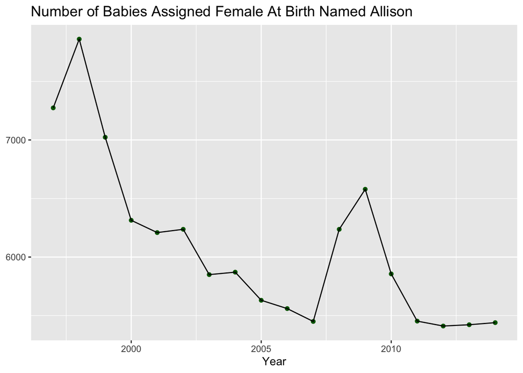

```r
bb_clean <- bb_clean |> select(Year, Female)

bb_clean|> ggplot(mapping = aes(x = Year, y = Female)) +
  geom_point(color = "darkgreen") +
  geom_line()+
  labs(title = "Number of Babies Assigned Female At Birth Named Allison", y = NULL) +
  theme(plot.title = element_text(size = 14))
```

Creating a Linear Model based to create $y = mx + b$ out putting a $\hat y$ for frequency based on the year.

```r
bb_lm <- bb_clean |> lm(Female ~ Year, data = _)
bb_lm
```

```
Call:
lm(formula = Female ~ Year, data = bb_clean)

Coefficients:
(Intercept)         Year
   209689.8       -101.5
```

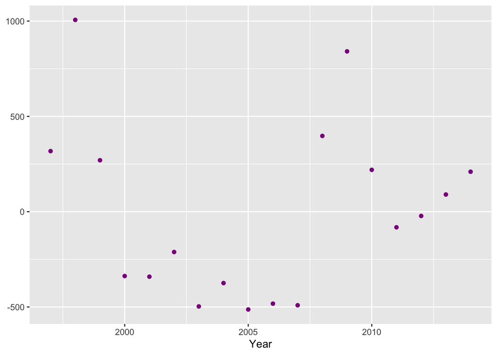

```r
bb_lm |> broom::augment() |>
  ggplot(aes(x = Year, y = .resid)) +
  geom_point(color = "darkmagenta") +
  labs(Title = "Residuals Based on Linear Model", y = NULL) +
  theme(plot.title = element_text(hjust = 0.5, size = 14) )
```

```r
broom::glance(bb_lm) |> select(r.squared)
```

```
# A tibble: 1 × 1
  r.squared
      <dbl>
1     0.584
```

**Interpretation of the Data.**  
The name Alison has been trending down in popularity since 1997. A linear model that models this trend predict lower than the number of babies named Alison in more recent years. Rare names are cool and it seems like people might be catching on based on the residuals. Also, with r squared value of 0.58 we can not place too much emphasis on the correlation of this trend.

# 3 Spelling by State

Babies can receive the same name with different spelling. the following code looks at the distribution of Alan, Allan, and Allen stratified by state.

```r
bb_clean <- bb_names |> filter(
  Name %in% c("Alan", "Allan", "Allen"),
  State == "CA" | State == "PA",
  Year == 2000,
  Sex == "M"
  )

bb_clean <- bb_clean |>
  group_by(State, Name) |>
  summarize(n = sum(Count))

bb_clean |>
  pivot_wider(names_from = Name, values_from = n,
              names_prefix = "Number spelled ",
              values_fill = 0)
```

```
# A tibble: 2 × 4
# Groups:   State [2]
  State `Number spelled Alan` `Number spelled Allan` `Number spelled Allen`
  <chr>                 <dbl>                  <dbl>                  <dbl>
1 CA                      579                    131                    176
2 PA                       51                     12                     56
```

```r
bb_clean |> group_by(State) |>
  mutate(percent = n/sum(n)*100) |>
  select(Name, State, percent) |>
  pivot_wider(names_from = Name, values_from = percent,
              names_prefix = "Percent spelled ",
              values_fill = 0)
```

```
# A tibble: 2 × 4
# Groups:   State [2]
  State `Percent spelled Alan` `Percent spelled Allan` `Percent spelled Allen`
  <chr>                  <dbl>                   <dbl>                   <dbl>
1 CA                      65.3                    14.8                    19.9
2 PA                      42.9                    10.1                    47.1
```

In California and in Pennsylvania the the spelling Allan had the lowest percent both states.